# Fundamentals and workflow for the R package Simumorph

**Alfredo Cortell-Nicolau<sup>1</sup>, Anne Kandler<sup>1</sup>**

<sup>1</sup> *Department of Human Behavior, Ecology and Culture, Max Planck Institute for Evolutionary Anthropology, Leipzig, Germany*

# 1 Introduction

The following document goes through the theoretical fundamentals on how to develop a discrete morphometric simulation of cultural artefacts (for the example, geometric microliths), and offers a reproducible workflow using the `Rpackage Simumorph`. This vignette will cover everything in detail, but very briefly here, the idea is to reproduce the variation from a shape A to a shape B across a $t$ number of discrete steps. To ensure the consistency among the shapes, we use a morphospace (a set of shapes provided by the user, ideally from observed data), from which we extract a covariance matrix that is used for multivariate sampling of new shapes. Using this covariance matrix to propose new shapes ensures that the structural relationships of the parameters of such shapes are consistent with the ones within the ‘observed’ data.

There are several elements that have to be considered to deploy the full simulation, and they are significantly interrelated. We have decided to explain each of these elements one by one, with several references to one another throughout the text, although the reader will probably have to bear with us while we go through each element until getting the full picture at the end. For the reader to understand what to expect on each section, a brief outline would be as follows:

1. *General theoretical approach*. Here we offer a brief theoretical overview of how outline-based Geometric Morphometrics (GMM) works. We also explain in some detail what a harmonic is and how its mathematical properties define it, since we will need those properties for the simulation.
2. *Toolbox*. Only using a covariance matrix might not be enough to ensure a consistent simulation, while staying within morphometrically plausible shapes. In this section we go through the different elements that we have used to deploy a realistic simulation.
3. *Model and simulation*. In this section we show our model. The model is based on sampling from a truncated normal multivariate distribution, where all the different caveats and restrictions have been explained in the section above.
4. *Simumorph*. It provides code and examples on how to perform all the above (e.g. the full simulation workflow) using `Simumorph`.

# 2 General theoretical approach

Geometric Morphometrics (GMM) is an approach developed in the field of Ecology, whose main objective is to measure and compare natural shapes (Bookstein, 1982; Claude, 2008; Rohlf & Archie, 1984). Here we focus on the technical details of how we use it in order to develop a diachronic simulation, or drift, of the morphometry of cultural artifacts. In our case, prehistoric arrowheads, or geometric microliths.

Our objective is to obtain shapes that undergo small but consistent variation for each step $t$ of the simulation. These shapes must meet the following conditions:

1. They must be functionally realistic (e.g. cannot contain line inter-crossings or wiggles)
2. Shape at $t$ depends on shape at $t-1$
3. Shape at $t$ must vary only slightly from shape at $t-1$

## 2.1 GMM (outline-based) fundamentals

To do this, we use outline-based geometric morphometrics, relying on Elliptic Fourier Decomposition (Claude, 2008; Kuhl & Giardina, 1982). Essentially, the general expression of the Fourier expansion for a periodic function $f(t)$ with $t \in \mathbb{R}$, of period $T$ and with $n$ number of harmonics, is defined as

$$f(t) = \frac{1}{2}a_0 + \sum_{n=1}^{\infty}[a_n \cos(\omega_n t)+b_n \sin(\omega_n t)], \tag{1}$$

where

$$\omega_n = n\frac{2\pi}{T} \tag{2}$$

is the angular frequency of the $n^{th}$ harmonic of the function (in radians), and where

$$a_n = \frac{2}{T}\int_{t_1}^{t_2}f(t)\cos(\omega_n t) dt \tag{3}$$

are the even Fourier coefficients, and

$$b_n = \frac{2}{T}\int_{t_1}^{t_2}f(t)\sin(\omega_n t) dt \tag{4}$$

are the odd Fourier coefficients.

These Fourier transforms, however, cannot be applied directly on outline analysis, since an outline is defined as a function of x and y-coordinates in two dimensions. Thus, the most common adopted solution is to use elliptic Fourier decomposition, by which the x and y coordinates are decomposed and expressed as functions of the curvilinear abscissa. In this framework the period $T$ is taken to be the outline perimeter. If we set the fundamental angular frequency $\omega = \frac{2\pi}{T}$, and let the curvilinear abscissa $t$ run from $0$ to $T$, then $x(t)$ and (y(t)$ can be expressed as follows:

$$x(t) = \frac{a_0}{2}+\sum_{j=1}^{+\infty}a_j \cos j \omega t + b_j \sin j \omega t \tag{5}$$

and

$$y(t) = \frac{c_0}{2}+\sum_{j=1}^{+\infty}c_j \cos j \omega t + d_j \sin j \omega t. \tag{6}$$

Here, and considering an outline with $k$ finite number of points, we can calculate discrete estimators for the different parameters as:

$$a_j = \frac{T}{2\pi^2j^2}\sum_{p=1}^{k}\frac{\Delta x_p}{\Delta t_p}\left(\cos\frac{2\pi j t_p}{T}-\cos\frac{2\pi jt_{p-1}}{T}\right) \tag{7}$$

with

$$\Delta x_1 = x_1-x_k$$

and

$$b_j = \frac{T}{2\pi^2j^2}\sum_{p=1}^{k}\frac{\Delta x_p}{\Delta t_p}\left(\sin\frac{2\pi j t_p}{T}-\sin\frac{2\pi jt_{p-1}}{T}\right) \tag{8}$$

with $c_j$ and $d_j$ calculated similarly for the $y$ coordinates. Because $a_0$ and $c_0$ are used for centering, these will not be explicitly modelled and, thus, our base equation becomes

$$x(t) = \sum_{j=1}^{+\infty}a_j \cos j \omega t + b_j \sin j \omega t \tag{9}$$

and similarly for $y(t)$.

Conceptually, it might be difficult to understand how periodic functions (e.g. sine waves) can produce sharp corners, or angular features. The short answer to this is that they cannot, but because the resolution of the representation increases as we add harmonics, with enough number of harmonics we can always obtain (or having the illusion to obtain) a specific angle, as pointed as it might be. If we were able to increase the size of our visualisation *ad infinitum* at some point we would see a rounded curve, but this would be of no visual nor analytical consequence if $j$ is high enough.

### 2.1.1 Harmonics

Fourier series were developed originally to work with so-called harmonics and harmonic ranges, and have known a significant development on different fields such as music, signal processing, electrical engineering and, of course, ecology and cultural studies. Understanding how harmonics work is crucial to understand how these are adapted in the context of outline-based geometric morphometrics. A harmonic can be defined as a sinusoidal wave with frequency multiple of a so-called fundamental frequency of a periodic signal (the 1st harmmonic). This implies that the way in which we structure the harmonics, as per Equation 1, and of course Equation 5 and Equation 6, is hierarchical. In other words, lower order harmonics have wider sinusoidal shapes, and model coarser morphometric features, whereas higher order harmonics have less impact on the general shape, but are the ones modelling finer grain details. As we will see, this has implications in how we develop a simulation, since these hierarchies must be respected through their parameter ranges if we want to obtain *credible* shapes consistently.

Each harmonic is governed by three mathematical properties: frequency ($f$), amplitude ($A$) and phase ($\phi$), which together define a sine wave according to:

$$S(t) = A \cos(\omega_t - \phi), \tag{10}$$

where $\omega = 2\pi f$ is the angular frequency, in radians, derived from the frequency $f$.

Now, we can individually explore each of these properties, and how they relate to $a_j$, $b_j$, $c_j$ and $d_j$, from now on, indistinctly referred to as Fourier parameters, as follows:

#### 2.1.1.1 (Angular) frequency

Frequency, as we have seen above, represents the number of cycles per second and is the reciprocal of the period $T$:

$$f = \frac{1}{T}.$$

From here, given the angular frequency $\omega = 2\pi f$, we can easily derive the value of angular frequency per $j_{th}$ hamonic ($\omega_j$) given in Equation 2. We can understand frequency as a parameter that governs the resolution of the sinewave, and because it is determined by $j$, it stays the same for any shape given equal $j$ and $T$. Thus, frequency will not be modelled, since it is deterministically defined by the number of harmonics, and its role within this framework is only to specify the resolution of each harmonic. An example of how frequency works can be seen below.

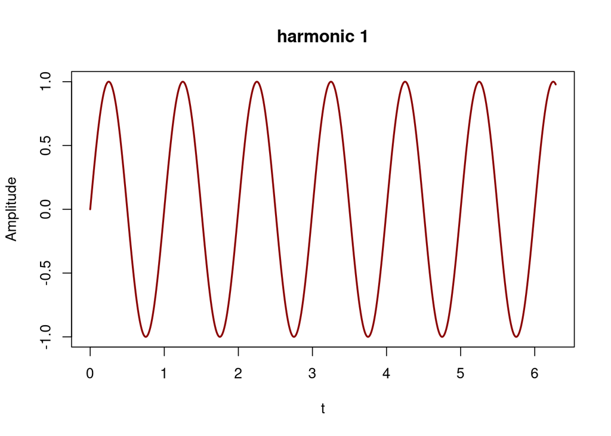

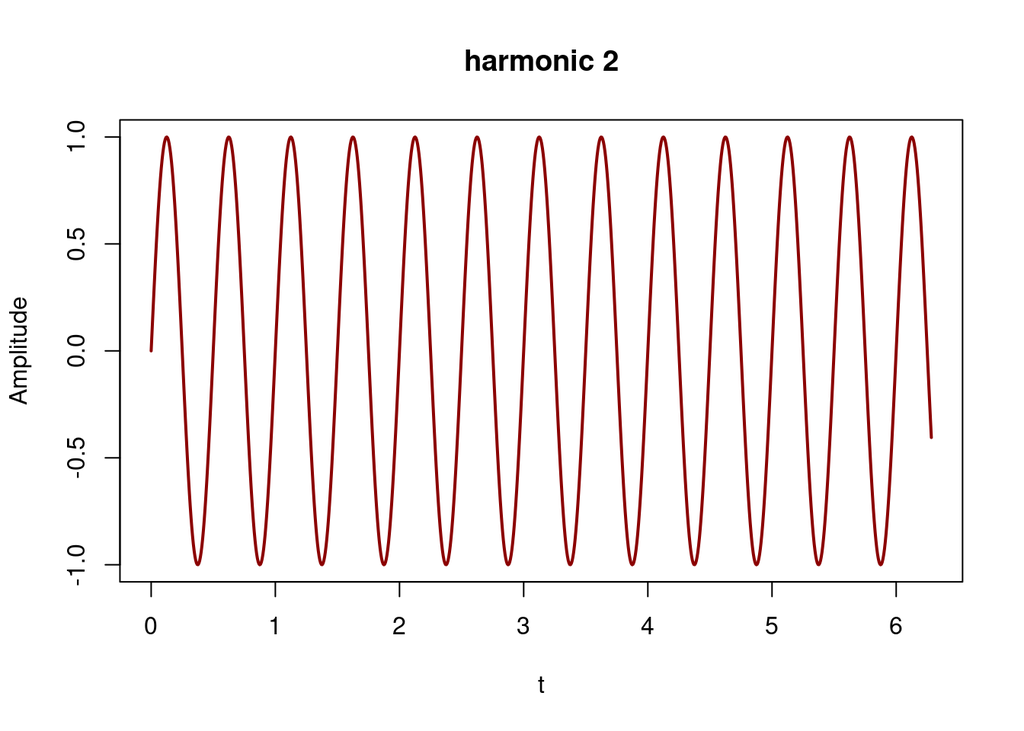

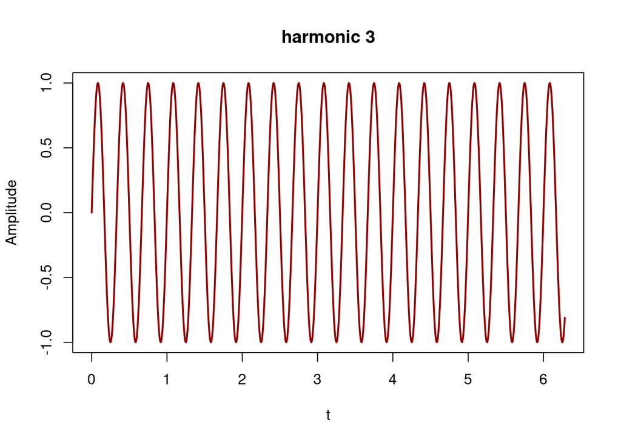

```r
# Define parameters
for (i in 1:3){
t <- seq(0, 2*pi, length.out = 1000)  # time or angle vector
A <- 1      # amplitude
f <- i      # frequency (Hz)
phi <- 0    # phase shift (radians)

# Generate the sinusoidal wave
y <- A * sin(2 * pi * f * t + phi)

# Plot the wave
plot(t, y, type = "l", col = "darkred", lwd = 2,
     xlab = "t", ylab = "Amplitude",
     main = paste0("harmonic ", i))
}
```

For the definition of the harmonics, the Fourier series use the four parameters $a_j$, $b_j$, $c_j$ and $d_j$. These parameters can be linked to amplitude ($A$) and phase ($\phi$).

#### 2.1.1.2 Amplitude

We can understand amplitude as the width, or range of our sinewave. In other words the difference between the maximum and minimum points on the y axis in our sinewave. Although it is not parameterised in Equation 5, it can be derived from the parameters $a_j$ and $b_j$ ($c_j$ and $d_j$ for Equation 6) as follows:

From Equation 5 we know that each harmonic is defined by:

$$a_j\cos(j\omega t) + b_j\sin(j\omega t).$$

We start with the trigonometric identity

$$\cos(\alpha - \beta) = \cos \alpha \cos \beta + \sin \alpha \sin \beta,$$

which, if applied with Equation 10, gives

$$A_j\cos(j\omega t - \phi_j) = A_j \cos (j\omega t) \cos (\phi_j) + A_j \sin (j\omega t) \sin (\phi_j).$$

We can then extract the matching terms from

$$a_j \cos(j\omega t) + b_j \sin (j\omega t) = A_j \cos (j\omega t) \cos (\phi_j) + A_j \sin (j\omega t) \sin (\phi_j)$$

to get

$$a_j = A_j\cos(\phi_j) \ \textrm{and} \ b_j = A_j\sin(\phi_j).$$

If we now want to compute $A_j$ for the parameters $a_j$ and $b_j$, we can square both equations

$$a_j^2 = A_j^2\cos^2(\phi_j)$$
$$b_j^2 = A_j^2\sin^2(\phi_j)$$

and add them
$$a_j^2+b_j^2=A_j^2\cos^2(\phi_j) + A_j^2\sin^2(\phi_j),$$

or

$$a_j^2+b_j^2 = A_j^2(\cos^2(\phi_j) + \sin^2(\phi_j)).$$

If we then use the Pythagorean identity

$$\cos^2(\phi_j) + \sin^2(\phi_j) = 1,$$

it reduces to

$$a_j^2+b_j^2 = A_j^2,$$

which finally gives us the amplitude as

$$A_j = \sqrt{a_j^2+b_j^2}. \tag{11}$$

Below we show changes in amplitude, given that the rest of parameters remain equal.

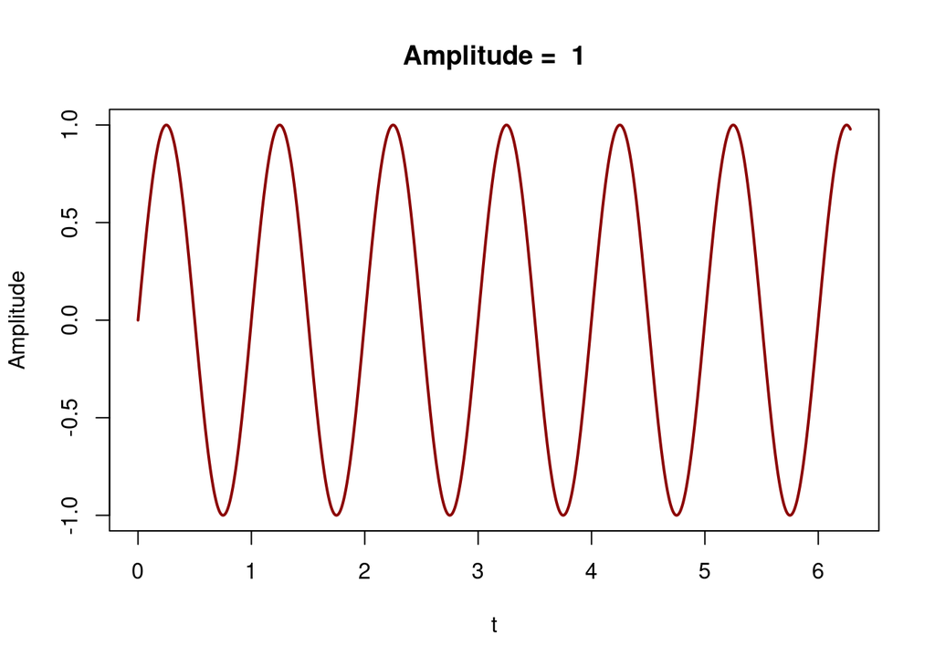

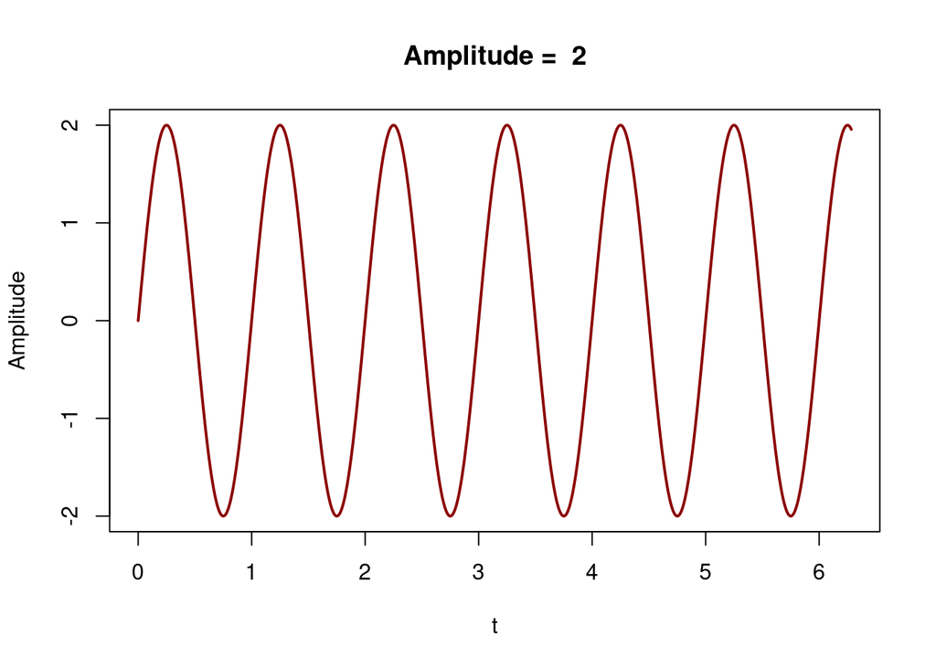

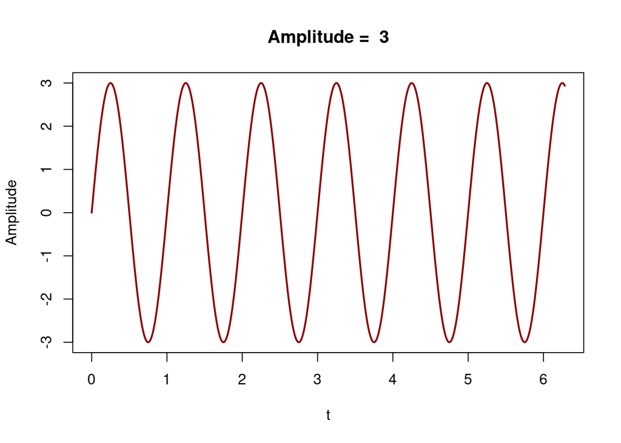

```r
# Define parameters
for (i in 1:3){
t <- seq(0, 2*pi, length.out = 1000)  # time or angle vector
A <- i      # amplitude
f <- 1      # frequency (Hz)
phi <- 0    # phase shift (radians)

# Generate the sinusoidal wave
y <- A * sin(2 * pi * f * t + phi)

# Plot the wave
plot(t, y, type = "l", col = "darkred", lwd = 2,
     xlab = "t", ylab = "Amplitude",
     main = paste0("Amplitude =  ", i))
}
```

#### 2.1.1.3 Phase

In plain words, $\phi$ tells us where ‘the wave starts’. As with $A$, it is not explicitly parameterised in Equation 5 but, as with $A$, it can be derived from it. If, from the derivation above, we consider

$$\frac{b_j}{a_j}=\frac{A_j\sin(\phi_j)}{A_j\cos(\phi_j)},$$

then, with basic trigonometry

$$\frac{b_j}{a_j}=\tan(\phi_j).$$

Solving for $\phi_j$, we get

$$\phi_j = \tan^-1\left(\frac{b_j}{a_j}\right),$$

or

$$\phi_j = \arctan \left(\frac{b_j}{a_j}\right). \tag{12}$$

We can observe how different $\phi$ values change the starting point of the wave in the plots below.

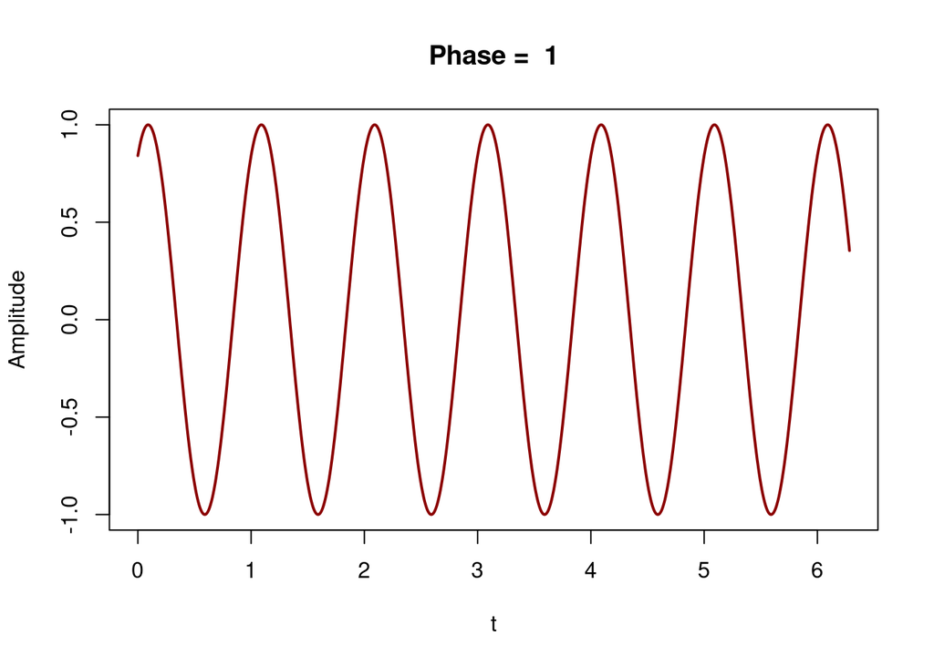

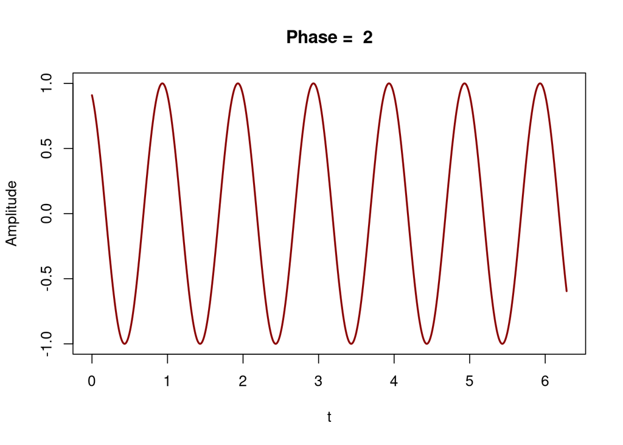

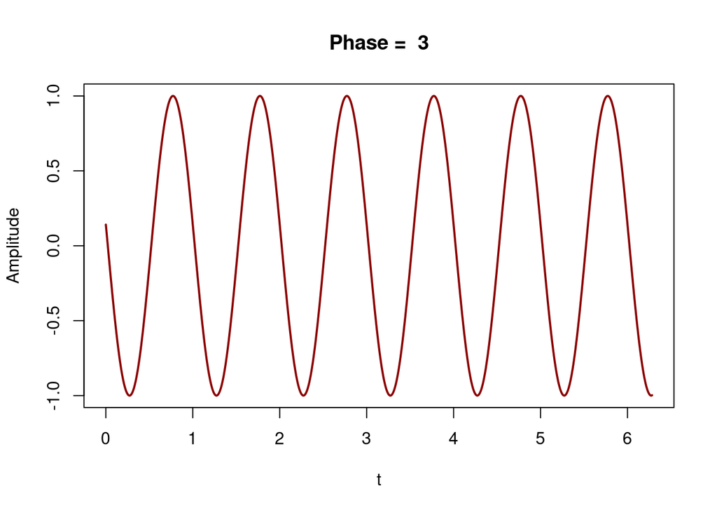

```r
# Define parameters
for (i in 1:3){
t <- seq(0, 2*pi, length.out = 1000)  # time or angle vector
A <- 1      # amplitude
f <- 1      # frequency (Hz)
phi <- i    # phase shift (radians)

# Generate the sinusoidal wave
y <- A * sin(2 * pi * f * t + phi)

# Plot the wave
plot(t, y, type = "l", col = "darkred", lwd = 2,
     xlab = "t", ylab = "Amplitude",
     main = paste0("Phase =  ", i))
}
```

### 2.1.2 Small recap

From the above it might be seen that a specific shape (or shape feature), which emerges from the combination of Equation 5 and Equation 6 for the x and y axes respectively, cannot be associated with one specific parameter value for any harmonic. Rather, it is the interplay between $\omega$, $A$ and $\phi$ which will finally result in one shape or another. This also means that these variables are not independent, and this must be taken into account to develop the simulation.

# 3 Toolbox

The objective of the simulation is to reproduce stochastic variation of specific shapes. It can be applied to any kind of artifact, but here we focus on geometric microliths, a specific type of prehistoric arrowhead used in many contexts and periods, but with special prevalence during the Early and Middle Holocene in Europe (see associated paper). Through previous work (Cortell-Nicolau et al., 2020, 2023), we have estimated that the best compromise between shape resolution and computational efficiency is to use 7 harmonics. However, and depending on the selected shape (for example, pottery shapes or tanged and barbed points), the number of necessary harmonics might differ.

Before we explicitly define the model and develop the simulation, there are several tools, resources, concepts and caveats that need to be discussed, as follows:

## 3.1 The Morphospace

Attending to Section 2, we have a total of four parameters per harmonic ($a_j$, $b_j$, $c_j$ and $d_j$) which in our case, leaves us with a total of 28 parameters per shape. These parameters are not independent, and it is their interplay which will finally result in one or another shape. In this scenario, it is not feasible to compute which parameter values would be necessary for any desired shape. To solve this, we have decided to use the **morphospace** as the main tool of our simulation. We can define the morphospace as an assemblage of the shapes that we would expect to find in the archaeological record, either from a theoretical or an empirical perspective. Its objective is to estimate parameter values from these known shapes, which will conform the main numeric input for our simulation. As we will see in the sections below, these parameter values will be used in many ways, from estimating parameters (Section 3.2.2) and restrictions (Section 3.2.3) to establish target points (Section 3.3) throughout the simulation or to produce the necessary covariance matrix (Section 3.2.1). The morphospace can be built from a set of known artifacts (e.g. artifacts that have been collected in the field and digitised). However, for the purpose of this simulation, we have decided to use well-known archaeological *types* as they were defined by Javier Fortea (1973) for the Iberian Mesolithic. Lengthier discussion on the problems of using archaeologically defined types can be found in the main manuscript, but we use them in this simulation for convenience because this allows us to address further problems, such as the effect of collinearity and small sample sizes on the covariance matrix, as we will see below.

We have, essentially, the following 28 types, as they were originally defined, and considering laterality as a marker for different types. If we have black .jpg files of these images, we can estimate the parameter values for each of these shapes, as stated in Section 2.1. We use the R package `Momocs` (Bonhomme et al., 2014) for this. The code below loads the different shapes of the morphospace, as well as produces some utilities and loads custom functions that will be needed further down the line. Our 28 original shapes would look as follows:

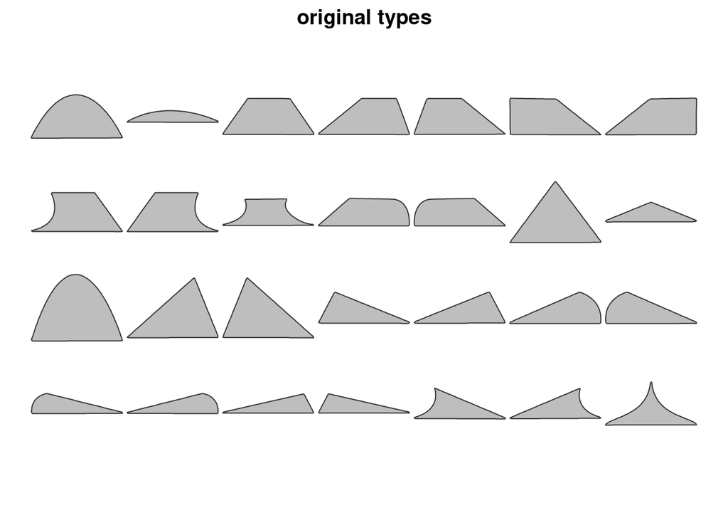

```r
#### STEP 1. Load the different outlines (produced in inkscape)

## Load outlines for GMM analysis and perform PCA to extract morphometric value
## We load already all the libraries that we will need further down the line

library(Momocs) ## For GMM functions
library(vegan) ## For manual Procrustes
library(tmvtnorm) ## For truncated multivariate normal
library(sf) ## to check internal intersections
library(matrixcalc) ## Check if the covariance matrix is positive definite

## Some utilities
harm_names <- c("h1", "h2", "h3","h4","h5","h6","h7") # Vector to rename subsequent objects
n.harm <- 7 # Number of harmonics
init <- 1 ## Which geometric will start the simulation
npts <- 120 ## Number of points to rebuild the outline

types <- c("G1.1", "G1.2", "G2", "G3.1", "G3.2", "G4.1",
       "G4.2", "G5.1", "G5.2", "G6", "G7.1", "G7.2",
       "G9", "G10", "G11", "G12.1", "G12.2", "G13.1",
       "G13.2", "G14.1", "G14.2", "G15.1", "G15.2",
       "G16.1", "G16.2", "G17.1", "G17.2", "G18")

## Extract outlines
dir <- getwd()
setwd("../inst/extdata/Parametric_space_outlines") ## Set your own path where the jpgs are
## Parametric_space_outlines is a folder with the oulines.jpgs of the shapes, and it is provided as data within the Simumorph package. It can also be found, individually, at github/acortell3/Simumorph. If the user has downloaded with the package. It can know the path where the files are by running system.file("extdata/Parametric_space_outlines", package = Simumorph"). Then the folder can be moved somewhere else, or the path can be directly substituted here.
set.seed(1)
geo_list <- c(1:28)
geo_list <- paste0(geo_list,".jpg")
geo_out <- Out(import_jpg(geo_list, auto.notcentered = T), fac = types)
setwd(dir)

## For simplicity, and to keep this part separated from the package workflow, we can define the functions 'phase' and 'amplitude' here, although they are included in the package.
phase <- function(x, coordinate = c("x","y")){
    coordinate <- match.arg(coordinate)
    if (coordinate == "x"){
        obj <- x[,c(1,2)]
    } else if (coordinate == "y"){
        obj <- x[,c(3,4)]
    }
    result <- apply(obj,1,function(x) atan2(x[1],x[2]))
    return(result)
}

amplitude <- function(x, coordinate=c("x","y","all")){
    coordinate <- match.arg(coordinate)
    if (coordinate == "x"){
        result <- apply(x,1,function(x) sqrt(x[1]^2+x[2]^2))
    } else if (coordinate == "y"){
        result <- apply(x,1,function(x) sqrt(x[3]^2+x[4]^2))
    } else if (coordinate == "all") {
        result <- apply(x,1,function(x) sqrt(x[1]^2+x[2]^2+x[3]^2+x[4]^2))
    }
    return(result)
}
## plot original outlines
panel(geo_out, dim = c(4,7), col = "gray", main = "original types")
```

From this point, we can estimate the parameter values for each of our 28 shapes, after centering and scale them through a General Procrustes Analysis (GPA), with the following line of code:

```r
morpho_pars <- efourier(coo_center(coo_scale(coo_alignxax(geo_out))),nb.h = n.harm, norm = F, start = T)
```

## 3.2 Shape variation

This section explains how we produce the shape variation given the morphospace described above. In order to simulate shapes from non-independent parameters, we will use a truncated multivariate normal distribution (see Section 4). Sampling from a multivariate normal distribution relies on a covariance matrix which, in our case, is obtained from the parameters extracted from the morphospace. In the following subsections, we explain (1) potential issues and solutions of the use of covariance matrices given typical parametric values in GMM, (2) further reasoning on our parameter choice and (3) some restrictions that are necessary to produce plausible shapes.

### 3.2.1 Covariance matrix

In order to sample from a multivariate normal distribution, we need to perform a Cholesky decomposition on the covariance matrix. This requires the matrix to be positive definite which, in turn, sets the requirements that this matrix is (1) large enough in relation with the number of covariates and (2) with low degree of collinearity. Likewise, in the associated paper we have also seen how some authors have used covariance matrices directly on the results of PCA analyses (e.g. Polly (2004)) and how this might not the best approach for our specific data, due to the *mosquito wing* problem.

#### 3.2.1.1 Sample size

We can address the problem of sample size through parametric linear interpolation. See, for instance, how it is used to produce the following shape sequence from shape A to shape B.

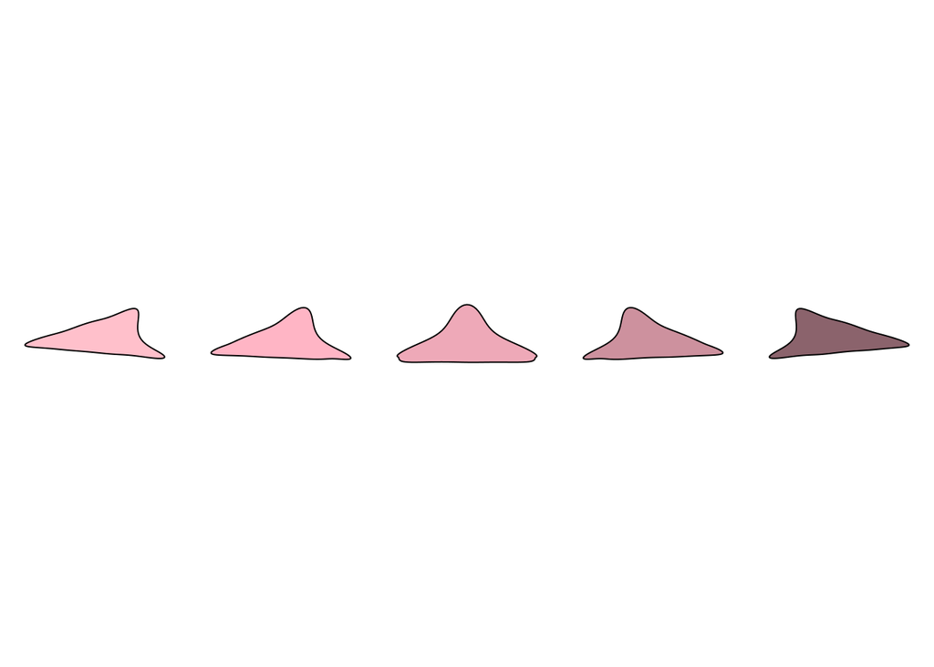

```r
## Load outlines for GMM analysis and perform PCA to extract morphometric value
types_li <- c("G17.1", "G17.2")

## Extract outlines
geo_out_li <- slice(geo_out, c(26,27))

## Estimate the parameters for the shapes within the morphospace
morpho_pars_li <- list() # to store the parameters

## Extract parameters of the two shapes
morpho_pars_li <- efourier(coo_center(coo_scale(coo_alignxax(geo_out_li))),nb.h = n.harm, norm = F, start = T)

## Interpolate linear values for three middle shapes
seq_list <- mapply(function(x,y) seq(x,y,length.out = 5),morpho_pars_li[1], morpho_pars_li[2], SIMPLIFY = FALSE)

## Assign them
sh1 <- morpho_pars_li[1]
sh2 <- sapply(seq_list, function(x) x[2])
sh3 <- sapply(seq_list, function(x) x[3])
sh4 <- sapply(seq_list, function(x) x[4])
sh5 <- morpho_pars_li[2]

shapes <- list(sh1,sh2,sh3,sh4,sh5) ## to iterate in loop

## Period values
P <- 1 ## P instead of T to avoid conflicts
p <- seq(0,1,length.out = npts)

colour <- c("pink","pink1","pink2","pink3","pink4")

## Rebuild and plot
par(mfrow = c(1,5), mar = c(1,1,1,1), oma = c(0.1,0.1,0.1,0.1))
for (i in 1:5){
    sh_pars <- list("an" = shapes[[i]][1:7],
            "bn" = shapes[[i]][8:14],
            "cn" = shapes[[i]][15:21],
            "dn" = shapes[[i]][22:28])
    ## Build shape coordinates according to Kuhl & Giardina, 1982, but for the paper we use the equivalent momocs function efourier_i()
    # Build X
    X <- rep(0,npts)
    for (h in 1:n.harm){
        H <- sh_pars$an[h]*cos((2*pi*h*p)/P)+sh_pars$bn[h]*sin((2*pi*h*p)/P)
        X <- X+H
    }

    # Build Y
    Y <- rep(0,npts)
    for (h in 1:n.harm){
        H <- sh_pars$cn[h]*cos((2*pi*h*p)/P)+sh_pars$dn[h]*sin((2*pi*h*p)/P)
        Y <- Y+H
    }

plot(X, Y, type = "n", asp = 1, xlab = "", ylab = "", axes = FALSE)
polygon(X, Y, col = colour[i], border = "black")

}
```

We can use this to increase our sample size, for example, producing pairwise mean shapes among our predefined shapes, which leaves us with a total of 406 shapes, as follows:

```r
expanded_ms <- list()
mat_index <- 1 ## Need this to populate the matrix
for (i in 1:length(types)){
    for (j in i:length(types)){
        shape <- apply(cbind(morpho_pars[i],morpho_pars[j]),1,mean)
        expanded_ms[[mat_index]] <- shape
        mat_index <- mat_index + 1
    }
}

#length(expanded_ms)

## Extract parameters without constants
par_vals <- sapply(expanded_ms,function(x) unlist(x))[c(0:length(types)),]
```

A caveat to have in mind is that a mean interpolated shape between any two existing shapes will not necessarily result on an existing, or even plausible shape itserlf. Therefore, and as discussed in the main paper, we visually explore the extended morphospace and discard the unplausible shapes, in order to build the covariance matrix.

#### 3.2.1.2 Collinearity

The procedure in the section above is just a straightforward proposal to increase our sample size. There are more sophisticated approaches but, in any case, because our new shapes will depend on linear interpolation, the collinearity of the parameters within our sample is not reduced. To solve this, we can switch to model with the mathematical properties of the wave $A_j$ and $\phi_j$ instead of the Fourier parameters using the equations explained in Section 2.1.1.2 and Section 2.1.1.3. This solves the collinearity problem because the computation of $\phi$ is based on periodic functions, which are not linear.

We can convert our estimated parameters $a_j$, $b_j$, $c_j$ and $d_j$ into $A_j$ and $\phi_j$ with the code below.

```r
## Matrix to store amplitude and phase
amp_pha_mat <- data.frame("Ax1" = rep(0,length(expanded_ms)), "Ay1" = rep(0,length(expanded_ms)), "Ax2" = rep(0,length(expanded_ms)), "Ay2" = rep(0,length(expanded_ms)), "Ax3" = rep(0,length(expanded_ms)), "Ay3" = rep(0,length(expanded_ms)), "Ax4" = rep(0,length(expanded_ms)),"Ay4" = rep(0,length(expanded_ms)),"Ax5" = rep(0,length(expanded_ms)), "Ay5" = rep(0,length(expanded_ms)), "Ax6" = rep(0,length(expanded_ms)), "Ay6" = rep(0,length(expanded_ms)), "Ax7" = rep(0,length(expanded_ms)), "Ay7" = rep(0,length(expanded_ms)),"Phix1" = rep(0,length(expanded_ms)), "Phiy1" = rep(0,length(expanded_ms)), "Phix2" = rep(0,length(expanded_ms)), "Phiy2" = rep(0,length(expanded_ms)), "Phix3" = rep(0,length(expanded_ms)), "Phiy3" = rep(0,length(expanded_ms)), "Phix4" = rep(0,length(expanded_ms)), "Phiy4" = rep(0,length(expanded_ms)), "Phix5" = rep(0,length(expanded_ms)), "Phiy5" = rep(0,length(expanded_ms)), "Phix6" = rep(0,length(expanded_ms)), "Phiy6" = rep(0,length(expanded_ms)), "Phix7" = rep(0,length(expanded_ms)), "Phiy7" = rep(0,length(expanded_ms)))

## Sort matrix per harmonic
harm1 <- t(par_vals[c(1,8,15,22),])
harm2 <- t(par_vals[c(2,9,16,23),])
harm3 <- t(par_vals[c(3,10,17,24),])
harm4 <- t(par_vals[c(4,11,18,25),])
harm5 <- t(par_vals[c(5,12,19,26),])
harm6 <- t(par_vals[c(6,13,20,27),])
harm7 <- t(par_vals[c(7,14,21,28),])

## Convert to list for looping
harms <- list(harm1,harm2,harm3,harm4,harm5,harm6,harm7)

## Populate with amplitudes (function comes from source)
index <- 1 ## For correspondence between list and matrix elements
for (i in 1:length(harms)){
    amp_pha_mat[,index] <- amplitude(harms[[i]], coordinate = "x")
    index <- index + 1
    amp_pha_mat[,index] <- amplitude(harms[[i]], coordinate = "y")
    index <- index + 1
}

## Populate with phases (function comes from source)
index <- 15 ## For correspondence between list and matrix elements
for (i in 1:length(harms)){
    amp_pha_mat[,index] <- phase(harms[[i]], coordinate = "x")
    index <- index + 1
    amp_pha_mat[,index] <- phase(harms[[i]], coordinate = "y")
    index <- index + 1
}
```

After this, we can produce a covariance matrix for each of our matrices (one using the Fourier parameters and another one produced with $A_j$ and $\phi_j$), and do some exploratory checks on their collinearity. For example, we can see how many of the pairwise correlations of our covariates are above certain threshold (e.g. 80% or 95%), or we can compute a value for mean collinearity as the mean of the pairwise collinearities.

```r
## Compute covariance matrices
linear_mat <- cov(t(par_vals))
amp_pha_cov <- cov(amp_pha_mat)

cols_li <- c()

for (i in 1:ncol(linear_mat)){
    for (j in 1:ncol(linear_mat)){
        if (i != j){
            val <- cor(linear_mat[,i],linear_mat[,j])
            cols_li <- append(cols_li,val)
        }
    }
}

cols_pha <- c()

for (i in 1:ncol(amp_pha_cov)){
    for (j in 1:ncol(amp_pha_cov)){
        if (i != j){
            val <- cor(amp_pha_cov[,i],amp_pha_cov[,j])
            cols_pha <- append(cols_pha,val)
        }
    }
}

col_res <- data.frame("Total length" = c(length(cols_li),length(cols_pha)),
              "Absolute correlation > 0.8" = c(length(which(abs(cols_li) > 0.8)),length(which(abs(cols_pha) > 0.8))),
              "Absolute correlation > 0.95" = c(length(which(abs(cols_li) > 0.95)),length(which(abs(cols_pha) > 0.95))),
              "Percentage absolute correlation > 0.8" = c(length(which(abs(cols_li) > 0.8))/length(cols_li),length(which(abs(cols_pha) > 0.8))/length(cols_pha)),
              "Percentage absolute correlation > 0.95" = c(length(which(abs(cols_li) > 0.95))/length(cols_li),length(which(abs(cols_pha) > 0.95))/length(cols_pha)),
              "Mean absolute correlation" = c(mean(abs(cols_li)), mean(abs(cols_pha))),
check.names = FALSE)

rownames(col_res) <- c("Fourier parameters", "Amplitudes and phases")

knitr::kable(col_res, format = "html", digits = 2)
```

|  | Total length | Absolute correlation > 0.8 | Absolute correlation > 0.95 | Percentage absolute correlation > 0.8 | Percentage absolute correlation > 0.95 | Mean absolute correlation |
| --- | --- | --- | --- | --- | --- | --- |
| Fourier parameters | 756 | 110 | 26 | 0.15 | 0.03 | 0.44 |
| Amplitudes and phases | 756 | 14 | 2 | 0.02 | 0.00 | 0.31 |

Finally, we can check how the matrix produced through the Fourier parameters is not positive definite, whilst the one produced with amplitudes and phases is positive definite.

```r
is.positive.definite(linear_mat)
```

```
[1] FALSE
```

```r
is.positive.definite(amp_pha_cov)
```

```
[1] TRUE
```

### 3.2.2 Parameters

The section above is one of the main reasons why we will produce our simulation relying on the mathematical properties of the harmonics ($A_j$ and $\phi_j$), rather than the Fourier parameters, but it is not the only one. Amplitude and phase (and frequency) are the actual variables that control a harmonic, independently of the methods used to define or analyse it (e.g. Fourier decomposition). In contexts like ours, with high parametric variance, the complex interplay between the different Fourier parameters eventually produces unplausible jumps and shapes during the simulation drift. Even having a covariance matrix, if the variance is high in highly dimensional spaces, small changes in our correlation structure might result in dramatic impacts on the shape produced, because working directly with parameters does not necessarily respect the amplitude and phase structure which ultimately produce the final shape. Even if they are forced to be dependent, small changes in the parameter values during the drift, where the values at $t$ depend on the values at $t-1$, might result in (1) not respecting the parameter hierarchies (e.g. higher order harmonics might have wider ranges than lower order harmonics) and (2) drift to extreme values for one or more parameters. Because working directly with the Fourier parameters does not necessarily establish an explicit link with the amplitude and phase of the harmonics, all of this might result in changes of phase or unstructured amplitudes which, in the last instance, end up producing unrealistically abrupt shape changes or, worst, unplausible shapes. In short, working ‘*blindly*’ with the Fourier parameters does not necessarily ensure that our amplitude and phase relationships are respected which, during drifts, ends up producing unrealistic shapes.

Thus, working directly with phase and amplitude gives a higher control of the harmonic shape. In any case, because Fourier parameters can easily be computed back from the resulting shapes, we can resort back to those on the simulated shapes in case we needed tests of common use within the GMM approach.

### 3.2.3 Restrictions

In order to assure a realistic and smooth simulation, we have established two restrictions as follows:

#### 3.2.3.1 Truncation on multivariate normal

One of the most important concepts is that of the harmonic hierarchy where $A_j > A_{j+1}$. While this is broadly addressed by the use of a covariance matrix, as we have seen above the parametric values can go to unrealistic ranges during drift. This also affects the phase values, with range $\phi_j[-\pi,\pi]$. In order to solve this, instead of sampling from a multivariate normal distribution, we use a truncated multivariate normal distribution, where we establish range boundaries for $A_j$ and $\phi_j$.

##### 3.2.3.1.1 Amplitude

The upper and lower thresholds for $A_j$ (we consider $x,y$ jointly) are defined by the ones observed in the parametric space. Let $\mathbf{A}$ be the section of the covariance matrix with the amplitude values from the shapes within our morphospace, with dimensions $I \times J$, where $A_{ij}$ is the $i$-th shape and the $j$-th harmonic. If $A_\max$ is the vector with the upper boundary for our truncated multivariate normal and $A_\min$ is the vector for the lower boundary, then:

$$\left[A_{\max}\right]_j = \max_{1 \leq i \leq I} A_{ij}, \qquad
\left[A_{\min}\right]_j = \min_{1 \leq i \leq I} A_{ij}.$$

This can be easily put into code as:

```r
## For code simplicity, here we work in the values of the full covariance matrix. The values for phase will be overriden in the code snippet in the next subsection.

upper_thres <- apply(amp_pha_mat,2,max)
lower_thres <- apply(amp_pha_mat,2,min)
```

##### 3.2.3.1.2 Phase

As for $\phi_j$, this is a bit trickier. As above, we can consider $\mathbf{P}$ the section of the covariance matrix with the phase values from the shapes of our morphospace, with dimensions $I \times J$, with $\phi_\max$ being the vector for the upper boundary and $\phi_\min$ the one for the lower boundary. Because phase is a circular variable, then its upper and lower thresholds are globably restricted by

$$\phi_\max = \pi, \qquad \phi_\min = -\pi.$$

But modelling the phase presents an additional challenge because certain extreme combinations of phase values such as, for example, $\mathrm{sin}(\phi_{x1}) \approx \mathrm{sin}(\phi_{yn})$ combined with $\mathrm{cos}(\phi_{x1}) \not\approx \mathrm{cos}(\phi_{yn})$, can give place to wiggly forms. To account for this, we have decided to include a local restriction, which solves this problem by smoothing the simulation overall and, combined with the target-based approach (Section 3.3), avoids sudden changes of phase. To do this, we include a threshold value $\alpha$, such that

$$\phi_{t-1} - \alpha < \phi_t < \phi_{t-1} + \alpha.$$

```r
phase_thres <- 0.5 ## Tau limit to allow phase variation

## Populate phases with the new values. The rows from amp_pha_mat here are randomly the shape 28. In the simulation it would be shape at t-1.
lower_thres[15:28] <- unlist(as.data.frame(amp_pha_mat[28,15:28])) - phase_thres
upper_thres[15:28] <- unlist(as.data.frame(amp_pha_mat[28,15:28])) + phase_thres

## If the obtained values exceed pi or -pi, bound to [-pi,pi]
lower_thres[15:28] <- pmin(pmax(lower_thres[15:28],-pi),pi)
upper_thres[15:28] <- pmin(pmax(upper_thres[15:28],-pi),pi)
```

#### 3.2.3.2 Restriction on crossing lines

The restrictions above impede sudden shape changes and unrealistic shapes (e.g. laces), but although they strongly reduce them, they do not completely avoid line intersections, which might still occasionally occurr in the extremes of the shapes. We avoid this algorithmically, by treating the shapes as spatial objects (just sets of $(x,y)$ coordinates) and applying the R function `st_is_valid`, from the R package `sf` (Pebesma & Bivand, 2023), which checks the topological validity of a given geometry. If the function returns an invalid geometry (e.g. line-intersection), the simulation candidate for $t$ is not accepted and it is resampled from $t-1$.

## 3.3 Targets

This is the final tool that we use to complete the simulation, and it is in combination with all of the above. Basically, each time a new shape is produced we compute the Procrustes distance between the shape and a given target and accept it only if it is below a specific threshold $\epsilon$.

This approach offers substantial versatility, since it can be implemented in very different ways. For instance, we might want to simulate the transition from a given shape A to a shape B, where phase B would be our target. We might also use in a way so that all our simulations remain relatively close to a specific given shape, or we can implement several target shapes to allow shifting among potential types without loosing morphometric plausability. Finally, if we want to give significant amounts of freedom to the evolutionary drift to explore on the emergence of previously unseen shapes, we can give a large value for $\epsilon$, which would effectively reduce the importance of the targets to a minimum and give more freedom to the simulation. All these different implementation methods are shown in the main manuscript, and additional supplementary material, and have been included in the provided R package.

# 4 Model and simulation

By now we know that we have an amplitude and phase value per coordinate and harmonic. Thus, from our morphometric space, we obtain the covariance matrix $\Sigma = 1/(N-1)M^TM$ with

$$\mathbf{M} = \begin{pmatrix}
V_1 \\
V_2 \\
\vdots \\
V_N
\end{pmatrix} =
\left(
\begin{array}{cccccccccccc}
A_{1}^{x1} & \cdots & A_{1}^{xn} & A_{1}^{y1} & \cdots & A_{1}^{yn} & \phi_{1}^{x1} & \cdots & \phi_{1}^{xn} & \phi_{1}^{y1} & \cdots & \phi_{1}^{yn} \\
A_{2}^{x1} & \cdots & A_{2}^{xn} & A_{2}^{y1} & \cdots & A_{2}^{yn} & \phi_{2}^{x1} & \cdots & \phi_{2}^{xn} & \phi_{2}^{y1} & \cdots & \phi_{2}^{yn} \\
\vdots & \ddots & \vdots & \vdots & \ddots & \vdots & \vdots & \ddots & \vdots & \vdots & \ddots & \vdots \\
A_{N}^{x1} & \cdots & A_{N}^{xn} & A_{N}^{y1} & \cdots & A_{N}^{yn} & \phi_{N}^{x1} & \cdots & \phi_{N}^{xn} & \phi_{N}^{y1} & \cdots & \phi_{N}^{yn}
\end{array}
\right).$$

From here, we can estimate each new shape as

$$\tilde{V}(t) \sim \mathcal{N}_T(\mu,\Sigma),$$

where

$$\mu = \begin{cases}
V_s & \text{if } t = 1 \\
V(t-1) & \text{if } t > 1,
\end{cases},$$

and $V_s$ represents the chosen initial shape at $t=1$. Attending to all of the above, we reproduce stochastic variation from one initial shape through 20 time steps with the following code:

*The code below will not run on a stand-alone, since it uses the objects and functions used in the previous chunks.*

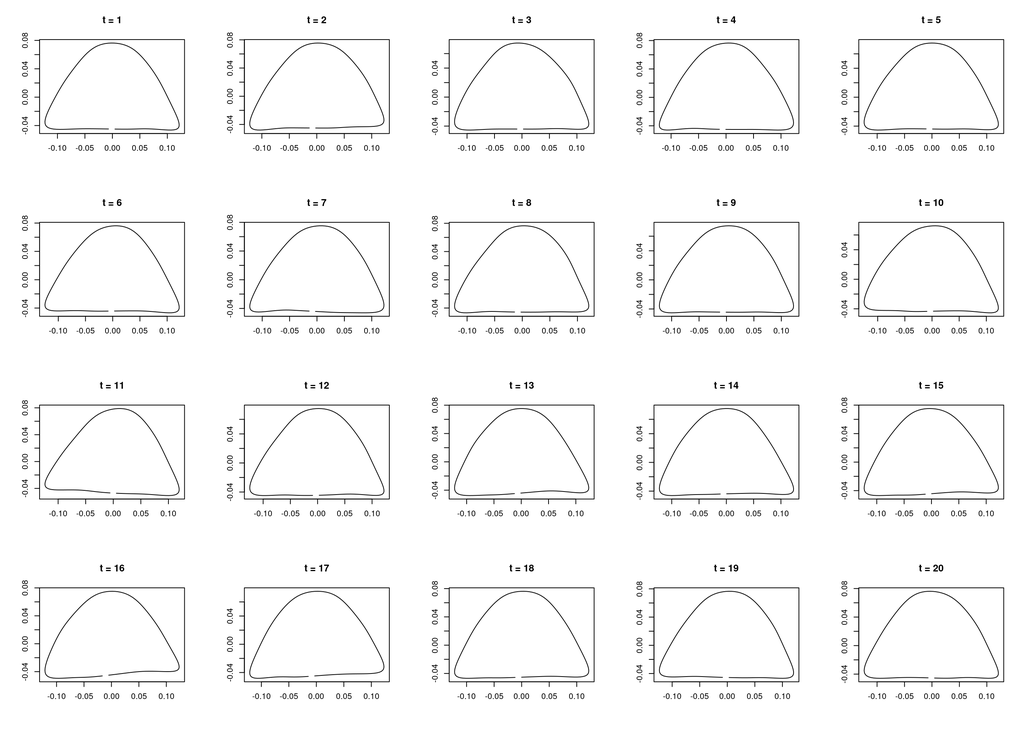

```r
sim <- 20 # number of simulations
amp_pha <- amp_pha_mat[init,] ## We start from G1.1

## Threshold for distance
proc_thres <- 0.5

## Store simulation figures
simuls <- list()

index <- 1

par(mfrow = c(4,5))

while (index <= sim){
    ## Set lower and upper threshold of the phases
    lower_thres[15:28] <- unlist(as.data.frame(amp_pha[15:28])) - phase_thres
    upper_thres[15:28] <- unlist(as.data.frame(amp_pha[15:28])) + phase_thres

    ## Bound phases to [-pi,pi]
    lower_thres[15:28] <- pmin(pmax(lower_thres[15:28],-pi),pi)
    upper_thres[15:28] <- pmin(pmax(upper_thres[15:28],-pi),pi)

    cand_vals <- rtmvnorm(1,mean = unlist(as.data.frame(amp_pha)), sigma = amp_pha_cov/100, lower = lower_thres, upper = upper_thres) # reduce the values of the covariance matrix without changing the correlation structure

    Ax <- cand_vals[c(1,3,5,7,9,11,13)]
    Ay <- cand_vals[c(2,4,6,8,10,12,14)]
    Phyx <- cand_vals[c(15,17,19,21,23,25,27)]
    Phyy <- cand_vals[c(16,18,20,22,24,26,28)]

    # Recompute parameters from amplitude and phase
    mat_par_vals <- data.frame("an" = Ax*sin(Phyx),
                   "bn" = Ax*cos(Phyx),
                       "cn" = Ay*sin(Phyy),
                       "dn" = Ay*cos(Phyy))

    ## Convert to list
    mat_par_vals_l <- list("an" = mat_par_vals[,1],
                 "bn" = mat_par_vals[,2],
                 "cn" = mat_par_vals[,3],
                 "dn" = mat_par_vals[,4])

    ## Build candidate_f
    candidate_f <- efourier_i(mat_par_vals_l, nb.h = n.harm, nb.pts = npts) # So far first shape
    candidate_f_check <- rbind(candidate_f,candidate_f[1,])## Close polygon for validity
    candidate_f_check <- st_polygon(list(candidate_f_check))

    if(st_is_valid(candidate_f_check)){
        ## Manually center, scale and rotate shapes for distance computation
        candidate_s <- coo_sample(coo_center(coo_scale(candidate_f)), n  = npts)

        ## Create reference object to compare distances. In this case, we compare every shape to G1.1, so it won't deviate much from it
        coeff_list <- list("an" = morpho_pars[1][1:7],
                   "bn" = morpho_pars[1][8:14],
                   "cn" = morpho_pars[1][15:21],
                   "dn" = morpho_pars[1][22:28])
        ref_shape <- efourier_i(coeff_list, nb.h = n.harm, nb.pts = npts) # So far first shape
        ref_shape <- coo_sample(ref_shape, n = 120)

        # Center
        ref_centered <- scale(ref_shape, scale = FALSE, center = TRUE)
        cand_centered <- scale(candidate_s, scale = FALSE, center = TRUE)

        # Scale to unit size
        ref_scaled <- ref_centered / sqrt(sum(ref_centered^2))
        cand_scaled <- cand_centered / sqrt(sum(cand_centered^2))

        # Rotate candidate for best match
        svd_result <- svd(t(ref_scaled) %*% cand_scaled)
        rotation_matrix <- svd_result$v %*% t(svd_result$u)
        cand_aligned <- cand_scaled %*% rotation_matrix

        ## Compute Procrustes distance
        proc_dist <- sqrt(procrustes(ref_scaled,cand_aligned,scale = TRUE)$ss)

        if (proc_dist <= proc_thres){
            plot(cand_aligned, type = "l", cex = 0.1, xlab = "", ylab = "", main = paste0("t = ",index))
            index <- index + 1
        }
    }
}
```

# 5 Simumorph

We have compiled all the above functions within the `Rpackage Simumorph`. Here we show a basic workflow of how a quick simulation would work. Let’s start by installing and loading the package.

```r
## Clean session to start with the package afresh
rm(list = ls(envir = .GlobalEnv), envir = .GlobalEnv) ## Remove previously loaded functions and objects
for (pkg in c("Momocs", "vegan", "tmvtnorm", "sf", "matrixcalc")) {
  try(detach(paste0("package:", pkg), unload = TRUE, character.only = TRUE), silent = TRUE)
} ## detach previously loaded packages

#install(devtools) if not installed
#devtools::install_github("acortell3/Simumorph")
library(Simumorph)
```

First, we need shapes, which we will use for our morphospace. In our case, the shapes provided above are included as example data within the package, and are ready to use, but we would advise (and encourage) the user to use its own empiric data. The object here is the same as above, so we can also plot them, again just as above.

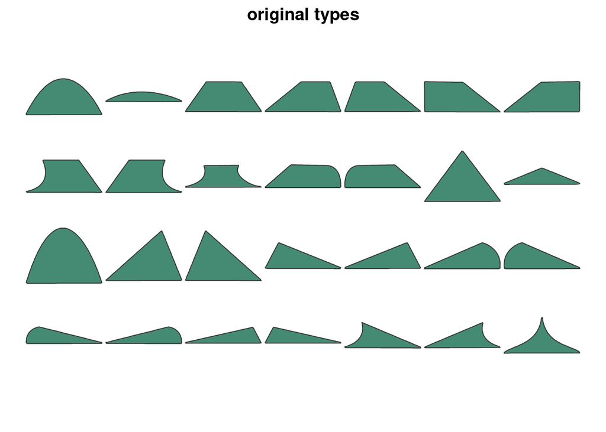

```r
data("geo_out")

## Plot it
Momocs::panel(geo_out, dim = c(4,7), col = "aquamarine4", main = "original types")
```

We have already seen in detail how each element is built within the package, so here we just need to go to the execution of the workflow. We need a morphospace and, in particular, an extended morphospace. We can easily build it as follows:

```r
## We can consider naming the shapes for clarity
types <- c("G1.1", "G1.2", "G2", "G3.1", "G3.2", "G4.1",
       "G4.2", "G5.1", "G5.2", "G6", "G7.1", "G7.2",
       "G9", "G10", "G11", "G12.1", "G12.2", "G13.1",
       "G13.2", "G14.1", "G14.2", "G15.1", "G15.2",
       "G16.1", "G16.2", "G17.1", "G17.2", "G18")
mrsp <- morphospace(x = geo_out, expand = T, mode = "mean", cov.mat = T, n.harm = 7, type.names = types)

## Extract only Amplitudes and phases for posterior management
mrsp_APhi <- mrsp[[2]]
## Extrac the covariance matrix
mrsp_cov <- mrsp[[3]]
```

With the code above we have built an extended morphospace (`expand = T`) from the provided shapes (`x = geo_out`) through pairwise linear interpolation (`mode = "mean"`, currently the only implemented method) with seven harmonics (`n.harm = 7`) per shape and type names extracted from the vector `types`. The resulting object is a list with three elements, where the first element is a list with the original Fourier coefficients, the second element a data frame with $A$ and $\phi$ values for each object within the extended morphometric space and the third is the resulting covariance matrix. If `cov.mat = F` the list has only two elements and the covariance matrix is not produced.

If necessary, we can also interpolate single shapes

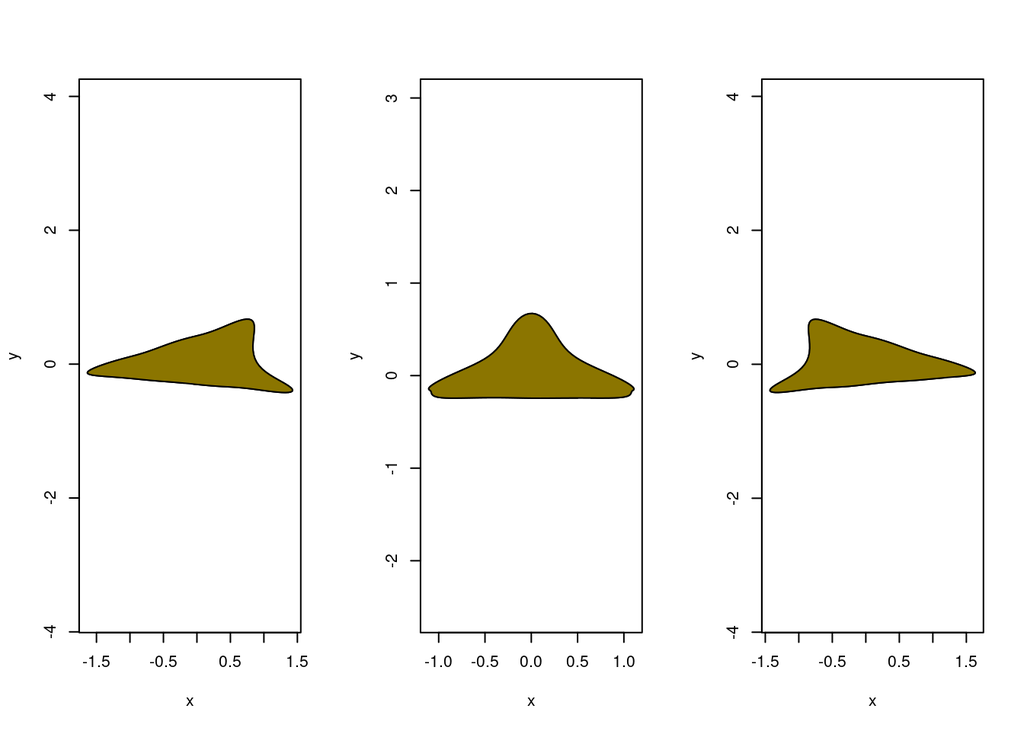

```r
## We interpolate a sequence of three intermediate shapes. Single shapes can also be interpolated. Read into the documentaion

## First, we extract the Fourier parameters for the interpolation
geo_out_li <- Momocs::slice(geo_out, c(26,27)) ## Select wto shapes

## Extract their Fourier parameters
morpho_pars_li <- list()
morpho_pars_li <- Momocs::efourier(Momocs::coo_center(Momocs::coo_scale(Momocs::coo_alignxax(geo_out_li))),nb.h = 7, norm = F, start = T)

## We can pass them to the function either as data frames, or lists
s1 <- data.frame("an" =  morpho_pars_li[1][1:7],
         "bn" =  morpho_pars_li[1][8:14],
         "cn" =  morpho_pars_li[1][15:21],
         "dn" =  morpho_pars_li[1][22:28])
s2 <- list("an" =  morpho_pars_li[2][1:7],
       "bn" =  morpho_pars_li[2][8:14],
       "cn" =  morpho_pars_li[2][15:21],
       "dn" =  morpho_pars_li[2][22:28])

## We interpolate three middle shapes
int_shape <- interpol_s(shape1 = s1, shape2 = s2, method = "sequence", npts = 120, fou.pars = T, n.shapes = 3)

## We can plot the interpolated shapes
par(mfrow = c(1,3))
for (i in 1:3){
    plot(int_shape[[i]]$Shape, type = "l", asp = 1)
    polygon(int_shape[[i]]$Shape, col = "gold4", asp = 1)
}
```

Currently, the main simulation can support four basic methods, as follows:

1. `"AtoA"`. An initial shape “A” is provided and the simulation stays broadly close to it, depending on the level $\epsilon$.
2. `"AtoB"`. An initial shape “A” and a target shape “B” are provided. The simulation slowly moves towards “B”.
3. `"AtoMult"`. An initial shape “A”, along with two or more target shapes (it can be the full morphospace) are provided. The simulation can move freely as long as it stays at $\epsilon$ distance from any or the provided shapes.
4. `"Free"`. An initial shape “A” is provided, but not targets. The simulation moves freely, and it can drift towards shapes that have not been observed within the archaeological record. If in the case 1 (“AtoA”), the value of $\epsilon$ is high, its results might approach this one.

We will focus on the case `"AtoB"`. The user could (and should) try with different modes. Let’s first make sure that our initial and target shapes are indeed the ones that we want through visual inspection. We can select them, and build single shapes from their $A_n$ and $\phi_n$ values using the function `build_s`. In the arguments below, essentially we load the shapes from the morphospace, specifying that it is one single shape (`sing.vals = F`), given a number of $x,y$ coordinate-points `np` and specifying that we do not want to extract the Fourier parameters as well (`fou.pars = F`), since we do not need them for the remainder of the simulation.

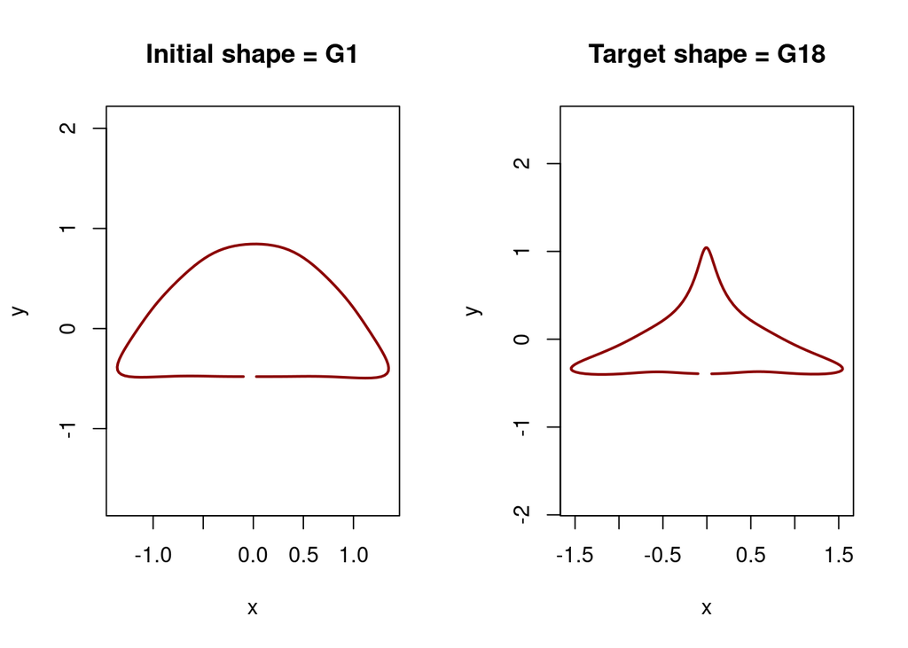

```r
## We find the number of x,y coordinates we want to extract
np <- 120

## Rebuild initial shape
init_shape <- build_s(x = mrsp_APhi[1,], sing.vals = F, fou.pars = F, npts = np)
## Rebuild target shape
target_shape <- build_s(x = mrsp_APhi[406,], sing.vals = F, fou.pars = F, npts = np)

par(mfrow = c(1,2))
plot(init_shape, type = "l", col = "darkred", lwd = 2, asp = 1, main = "Initial shape = G1")
plot(target_shape, type = "l", col = "darkred", lwd = 2, asp = 1, main = "Target shape = G18")
```

We can compute the Procrustes distance from these two shapes in order to have a reference for the value of $\epsilon$ during the simulation.

```r
proc_dist(shape1 = init_shape, shape2 = target_shape, multi = F)
```

```
Procrustes distance
          0.2273362
```

With all of the above, we can finally perform the simulation. Let’s consider a simulation where we will go from shape A to shape B, allowing an initial distance of $\epsilon = 0.25$, based on the distance computed above. In this case, we will only produce the shapes (`only.shapes = T`) and we will allow the simulation to run for 100 times (`sim = 100`). While running the function, the step of the simulation is printed for guidance to the user. We only show 20 shapes, from the full 100 due to space reasons. The parameter `max.attempts` is there because, if $\epsilon$ is too low, the simulation might get stuck. Usually, this parameter stops the function if the number of attempts without distances lower to $\epsilon$ reaches the value in `max.attempts` (default is 500), and an error message is generated, advising to increase $\epsilon$. The case of the method “AtoB” is special. This is because $\epsilon$ works differently here. Here, a simulation at step $t$ is accepted if the distance from that simulation to the target is lower than the distance at $t-1$. By definition, and for a long sequence, this can get the chain stuck. In this case, and after the number of attempts in `max.attempts` is reached, $\epsilon$ is increased and a warning is issued informing on where at which $t$ has $\epsilon$ been increased. Finally, the parameter `speedAtoB` (not shown below) acts only on this `AtoB` scenario, and allows for an artificial increase (or decrease) of $\epsilon$ at each $t$, allowing a greater control over the timing of the simulation.

```r
set.seed(123)
results <- simumorph(x = mrsp_cov, m.space = mrsp_APhi, init = 1, target = 406, method = "AtoB", sim = 100, npts = np, a = 0.4, e = 0.25, f = 100, only.shapes = T, max.attempts = 500)
```

```
[1] 1
[1] 2
[1] 3
[1] 4
[1] 5
[1] 6
[1] 7
[1] 8
[1] 9
[1] 10
[1] 11
[1] 12
[1] 13
[1] 14
[1] 15
```

[output cut: 85 more lines]

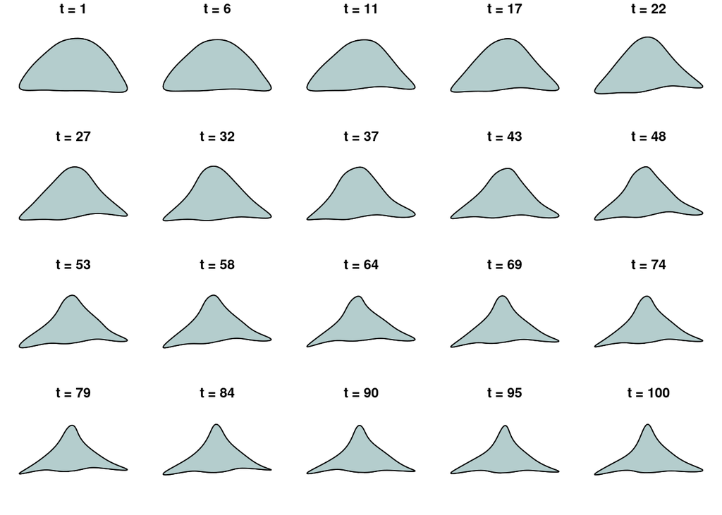

```r
## Build a vector to select 20 shapes from the provided 100
shape_index <- round(seq(1,100,length.out = 20))

par(mfrow = c(4,5), mar = c(1,1,1,1), oma = c(0.1,0.1,0.1,0.1))
for (i in 1:20){
    plot(results[[shape_index[i]]], asp = 1, type = "l", xlab = "", ylab = "", main = paste0("t = ",shape_index[[i]]), axes = F)
    polygon(results[[shape_index[i]]], asp = 1, col = "lightcyan3")

}
```

From here, the user can start playing with the different options of the package (also look into help() for function specs). More vignettes and functions (hopefully) coming soon!

## 6 References

Bonhomme, V., Picq, S., Gaucherel, C., & Claude, J. (2014). Momocs: Outline Analysis Using R. *Journal of Statistical Software*, *56*(13), 1–24.

Bookstein, F. L. (1982). Foundations of Morphometrics. *Annual Review of Ecology and Systematics*, *13*, 451–470. https://www.jstor.org/stable/2097076

Claude, J. (2008). *Morphometrics with R*. Springer-Verlag.

Cortell-Nicolau, A., García-Puchol, O., & Juan-Cabanilles, J. (2023). The geometric microliths of cueva de la cocina and their significance in the mesolithic of Eastern Iberia: A morphometric study. *Quaternary International*, *677-678*, 51–64. https://doi.org/10.1016/j.quaint.2023.05.014

Cortell-Nicolau, A., García-Puchol, O., & Shennan, S. (2020). Cultural continuities and discontinuities at the Neolithic transition in Eastern Iberia: An analysis of the morphometry of geometric microliths. *Archaeological and Anthropological Sciences*, *12*(11), 253. https://doi.org/10.1007/s12520-020-01204-0

Fortea, J. (1973). *Los complejos microlaminares y geométricos del Epipaleolítico mediterráneo español* [PhD thesis]. Universidad de Salamanca.

Kuhl, F. P., & Giardina, C. R. (1982). Elliptic Fourier features of a closed contour. *Computer Graphics and Image Processing*, *18*(3), 236–258. https://doi.org/10.1016/0146-664X(82)90034-X

Pebesma, E., & Bivand, R. (2023). *Spatial Data Science: With Applications in R*. Chapman; Hall/CRC. https://doi.org/10.1201/9780429459016

Polly, P. D. (2004). On the simulation of the evolution of morphological shape: Multivariate shape under selection and drift. *Palaeontologia Electronica*, *7*(2), 7.2.7A.

Rohlf, F. J., & Archie, J. W. (1984). A Comparison of Fourier Methods for the Description of Wing Shape in Mosquitoes (Diptera: Culicidae). *Systematic Zoology*, *33*(3), 302–317. https://doi.org/10.2307/2413076